```python
import pandas as pd
import numpy as np
```

# Aggregation

Agregation is reducing the column(s) to individual number.

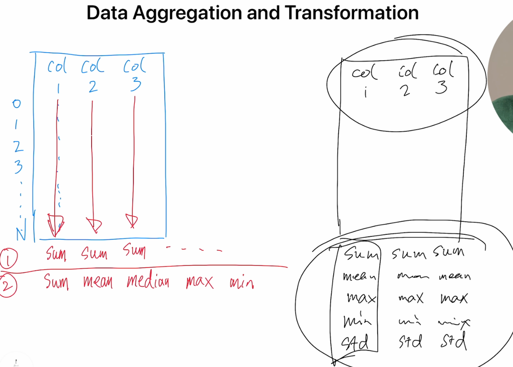

```python
from IPython.display import Image
display(Image(filename='./samples_rw/aggregation.png', width=500))
```

# Transformation

Transformation gives the same column numbers in the result as the numbers from the column.

We transforms the column to new columns values with the same number of items from the column.

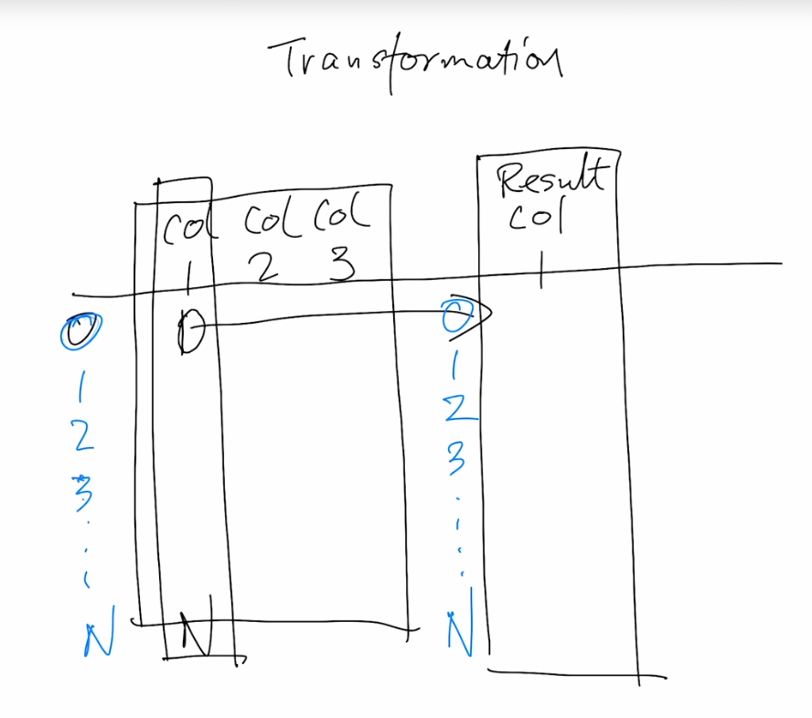

```python
from IPython.display import Image
display(Image(filename='./samples_rw/transformation.png', width=500))
```

In this example below we parse the date exactly in the data set row.

parse_dates = [ list of columns which suppost to be a dates ]. Even it is a single column we need to apply the list, here.

```python
data = pd.read_csv('./samples_rw/aggregation/realtor-data.csv', parse_dates=['prev_sold_date'])
data.sample(4)
```

|  | status | bed | bath | acre_lot | city | state | zip_code | house_size | prev_sold_date | price |
| --- | --- | --- | --- | --- | --- | --- | --- | --- | --- | --- |
| 659678 | for_sale | 2.0 | NaN | 0.05 | Philadelphia | Pennsylvania | 19124.0 | 1560.0 | 2012-05-04 | 184900.0 |
| 799381 | for_sale | 1.0 | 1.0 | NaN | New York | New York | 11238.0 | 700.0 | 2013-10-08 | 655000.0 |
| 333562 | for_sale | 2.0 | 3.0 | 78.00 | Newbury | Vermont | 5051.0 | 2943.0 | NaT | 697900.0 |
| 635538 | for_sale | 3.0 | 3.0 | NaN | Beach Haven West | New Jersey | 8050.0 | 2491.0 | 2006-01-12 | 899000.0 |

```python
data['price'].mean()
```

```
np.float64(877438.1583343924)
```

Median: 50% of all houses for sale are below the medium, and 50% of sale are above the medium.

```python
data['price'].median()
```

```
np.float64(475000.0)
```

I need to pass list of the columns for statistics. Therefore, the list must be applied.

```python
data[['bed', 'bath', 'acre_lot', 'house_size','price']].median()
```

```
bed                3.00
bath               2.00
acre_lot           0.29
house_size      1650.00
price         475000.00
dtype: float64
```

# agg( ) / aggregate ( )

Agg( ) and aggregate ( ) the same functions. We can aggregate the data in one run.

```python
data['price'].agg(['mean', 'median', 'max', 'min', 'std'])
```

```
mean      8.774382e+05
median    4.750000e+05
max       8.750000e+08
min       0.000000e+00
std       2.457698e+06
Name: price, dtype: float64
```

Matrix of aggregations:

Multiple columns with multiple aggregation values.

```python
data[['bed', 'bath', 'acre_lot', 'house_size','price']].agg(['mean', 'median', 'max', 'min', 'std'])
```

|  | bed | bath | acre_lot | house_size | price |
| --- | --- | --- | --- | --- | --- |
| mean | 3.332190 | 2.484236 | 17.317292 | 2.138437e+03 | 8.774382e+05 |
| median | 3.000000 | 2.000000 | 0.290000 | 1.650000e+03 | 4.750000e+05 |
| max | 123.000000 | 198.000000 | 100000.000000 | 1.450112e+06 | 8.750000e+08 |
| min | 1.000000 | 1.000000 | 0.000000 | 1.000000e+02 | 0.000000e+00 |
| std | 2.065312 | 1.931622 | 970.707378 | 3.046600e+03 | 2.457698e+06 |

Specific functions for specific columns.

Do not repeat the value in the dictionary as will be ignored previous one!

This method is the same as we seen above. Maybe a little more clear using dictionary instead of two functions.

```python
# dict inside the agg()
data.agg({'bed': 'median',
          'bath': 'max',
          'house_size': 'mean',
          'price':'std'
          })
```

```
bed           3.000000e+00
bath          1.980000e+02
house_size    2.138437e+03
price         2.457698e+06
dtype: float64
```

## idxmax - max

idxmax - is the index number, for the maximum value. We can easly find this value in the dataset.

Let's look at this row (this property) and check it.

```python
data['price'].agg(['idxmax', 'max'])
```

```
idxmax       572886.0
max       875000000.0
Name: price, dtype: float64
```

```python
data.loc[572886, ]
```

```
status                       for_sale
bed                               9.0
bath                              2.0
acre_lot                          NaN
city                            Bronx
state                        New York
zip_code                      10458.0
house_size                     2440.0
prev_sold_date    2002-12-30 00:00:00
price                     875000000.0
Name: 572886, dtype: object
```

Now, let's find the lowest price property from the dataframe:

We can apply the index formula instead of index number (hard coding) in the code.

```python
data.loc[data.price.idxmin(),]
```

```
status              for_sale
bed                      NaN
bath                     NaN
acre_lot                0.17
city                Paterson
state             New Jersey
zip_code              7504.0
house_size            4500.0
prev_sold_date           NaT
price                    0.0
Name: 465599, dtype: object
```

We can find the property with the max bedrooms:

```python
data.loc[data.bed.idxmax()]
```

```
status                       for_sale
bed                             123.0
bath                            123.0
acre_lot                          NaN
city                    New York City
state                        New York
zip_code                      10471.0
house_size                        NaN
prev_sold_date    2012-06-29 00:00:00
price                     120000000.0
Name: 536923, dtype: object
```

https://pandas.pydata.org/docs/user_guide/groupby.html#aggregation

Pandas aggregation functions: Method

Description

any ( )

Compute whether any of the values in the groups are truthy

all ( )

Compute whether all of the values in the groups are truthy

count( )

Compute the number of non-NA values in the groups

cov() *

Compute the covariance of the groups

first()

Compute the first occurring value in each group

idxmax()

Compute the index of the maximum value in each group

idxmin()

Compute the index of the minimum value in each group

last()

Compute the last occurring value in each group

max()

Compute the maximum value in each group

mean()

Compute the mean of each group

median()

Compute the median of each group

min()

Compute the minimum value in each group

nunique()

Compute the number of unique values in each group

prod()

Compute the product of the values in each group

quantile()

Compute a given quantile of the values in each group

sem()

Compute the standard error of the mean of the values in each group

size()

Compute the number of values in each group

skew() *

Compute the skew of the values in each group

std()

Compute the standard deviation of the values in each group

sum()

Compute the sum of the values in each group

var()

Compute the variance of the values in each group

```python
data['price'].agg(['count', 'size'])
```

```
count    904895
size     904966
Name: price, dtype: int64
```

count = shows not missed values

size = shows all values even when not available

```python
data.shape
```

```
(904966, 10)
```

```python
# give me all the records without the price
data.loc[data.price.isna(),]
# gives all indices matched to the price NaN
```

|  | status | bed | bath | acre_lot | city | state | zip_code | house_size | prev_sold_date | price |
| --- | --- | --- | --- | --- | --- | --- | --- | --- | --- | --- |
| 619434 | ready_to_build | 4.0 | NaN | NaN | Medford | New Jersey | 8055.0 | 2244.0 | NaT | NaN |
| 619444 | ready_to_build | 3.0 | NaN | NaN | Mount Laurel | New Jersey | 8054.0 | 2224.0 | NaT | NaN |
| 619445 | ready_to_build | 3.0 | NaN | NaN | Mount Laurel | New Jersey | 8054.0 | 2270.0 | NaT | NaN |
| 620249 | ready_to_build | 2.0 | NaN | NaN | Moorestown | New Jersey | 8057.0 | 1748.0 | NaT | NaN |
| 620325 | ready_to_build | 2.0 | NaN | NaN | Moorestown | New Jersey | 8057.0 | 1865.0 | NaT | NaN |
| ... | ... | ... | ... | ... | ... | ... | ... | ... | ... | ... |
| 685698 | ready_to_build | 5.0 | NaN | NaN | Middletown | Delaware | 19709.0 | 2511.0 | NaT | NaN |
| 685699 | ready_to_build | 5.0 | NaN | NaN | Middletown | Delaware | 19709.0 | 2814.0 | NaT | NaN |
| 701728 | ready_to_build | 3.0 | NaN | NaN | Mount Holly | New Jersey | 8060.0 | 2208.0 | NaT | NaN |
| 702663 | ready_to_build | 4.0 | NaN | NaN | Medford | New Jersey | 8055.0 | 2244.0 | NaT | NaN |
| 703119 | ready_to_build | 3.0 | NaN | NaN | Mount Holly | New Jersey | 8060.0 | 2208.0 | NaT | NaN |

71 rows × 10 columns

# statistic functions

```python
data[['bed', 'price', 'bath']].agg(['var', 'sem', 'std', 'skew', 'sum' ])
```

|  | bed | price | bath |
| --- | --- | --- | --- |
| var | 4.265513e+00 | 6.040279e+12 | 3.731165e+00 |
| sem | 2.345846e-03 | 2.583625e+03 | 2.171758e-03 |
| std | 2.065312e+00 | 2.457698e+06 | 1.931622e+00 |
| skew | 8.755577e+00 | 1.551964e+02 | 3.389897e+01 |
| sum | 2.582867e+06 | 7.939894e+11 | 1.965234e+06 |

# Build aggregation

we can define our functions from the built aggregation puzzles. Our function are build on object variables, so they have not any qoutation.

We can mix our functions with the built-in functions in pandas, what is a beauty!

```python
from numpy._core.fromnumeric import mean
def mean_less_median(x):
  return x.mean() - x.median()

def range(x):
  return x.max() - x.min()

data[['bed', 'bath', 'price']].agg([mean_less_median, range, 'sum', 'median'])
```

|  | bed | bath | price |
| --- | --- | --- | --- |
| mean_less_median | 3.321899e-01 | 4.842355e-01 | 4.024382e+05 |
| range | 1.220000e+02 | 1.970000e+02 | 8.750000e+08 |
| sum | 2.582867e+06 | 1.965234e+06 | 7.939894e+11 |
| median | 3.000000e+00 | 2.000000e+00 | 4.750000e+05 |

# Transformation in practice

transformation gives the same results from the columns to new column.

Always convert the date from the strings to the correct date format at the begining of the data preparation.

```python
realtor_data = pd.read_csv('./samples_rw/aggregation/realtor-data.csv', parse_dates=['prev_sold_date'])
forex_data = pd.read_csv('./samples_rw/aggregation/exchange_rates.csv', parse_dates=['date'])
```

```python
realtor_data
```

|  | status | bed | bath | acre_lot | city | state | zip_code | house_size | prev_sold_date | price |
| --- | --- | --- | --- | --- | --- | --- | --- | --- | --- | --- |
| 0 | for_sale | 3.0 | 2.0 | 0.12 | Adjuntas | Puerto Rico | 601.0 | 920.0 | NaT | 105000.0 |
| 1 | for_sale | 4.0 | 2.0 | 0.08 | Adjuntas | Puerto Rico | 601.0 | 1527.0 | NaT | 80000.0 |
| 2 | for_sale | 2.0 | 1.0 | 0.15 | Juana Diaz | Puerto Rico | 795.0 | 748.0 | NaT | 67000.0 |
| 3 | for_sale | 4.0 | 2.0 | 0.10 | Ponce | Puerto Rico | 731.0 | 1800.0 | NaT | 145000.0 |
| 4 | for_sale | 6.0 | 2.0 | 0.05 | Mayaguez | Puerto Rico | 680.0 | NaN | NaT | 65000.0 |
| ... | ... | ... | ... | ... | ... | ... | ... | ... | ... | ... |
| 904961 | for_sale | 2.0 | 2.0 | NaN | New York City | New York | 10463.0 | NaN | 2021-08-13 | 359000.0 |
| 904962 | for_sale | 2.0 | 2.0 | NaN | Bronx | New York | 10463.0 | 1200.0 | NaT | 299000.0 |
| 904963 | for_sale | NaN | 1.0 | NaN | Bronx | New York | 10463.0 | NaN | NaT | 120000.0 |
| 904964 | for_sale | 3.0 | 2.0 | NaN | Bronx | New York | 10463.0 | NaN | NaT | 449000.0 |
| 904965 | for_sale | 3.0 | 3.0 | NaN | New York City | New York | 10463.0 | 1677.0 | 2007-06-27 | 850000.0 |

904966 rows × 10 columns

```python
forex_data.sample(3)
```

|  | date | EUR | GBP | INR | AUD | CAD | SGD | CHF | MYR | JPY | ... | SAR | ZAR | LKR | SEK | TWD | THB | TTD | TRY | AED | VEF |
| --- | --- | --- | --- | --- | --- | --- | --- | --- | --- | --- | --- | --- | --- | --- | --- | --- | --- | --- | --- | --- | --- |
| 315 | 2021-12-17 | 0.886862 | 0.753798 | 76.100193 | 1.399213 | 1.283135 | 1.364208 | 0.922899 | 4.219391 | 113.566149 | ... | 3.75 | 15.859988 | 202.127302 | 9.099786 | 27.818012 | 33.325631 | 6.793844 | 16.274925 | 3.6725 | 460678.979914 |
| 1090 | 2019-11-03 | 0.895680 | 0.773259 | 70.525212 | 1.447996 | 1.315203 | 1.357634 | 0.985571 | 4.166430 | 108.193312 | ... | 3.75 | 15.029690 | 181.169865 | 9.632469 | 30.477735 | 30.171774 | 6.778249 | 5.702601 | 3.6725 | 9.987500 |
| 1535 | 2018-08-15 | 0.882587 | 0.788140 | 70.222294 | 1.382605 | 1.315852 | 1.380673 | 0.994643 | 4.102890 | 110.677914 | ... | 3.75 | 14.612765 | 160.159966 | 9.225927 | 30.871795 | 33.351437 | 6.739491 | 6.028149 | 3.6725 | 9.987500 |

3 rows × 54 columns

Check the range of the data we use in the dataframe: max - min.

```python
forex_data.date.agg(['min', 'max'])
```

```
min   2012-01-01
max   2022-10-28
Name: date, dtype: datetime64[ns]
```

```python
def data_range(x):
  return x.max() - x.min()

forex_data.date.agg(data_range)
```

```
Timedelta('3953 days 00:00:00')
```

```python
forex_data.shape
```

```
(3954, 54)
```

```python
forex_data[['date']].agg(['max', 'min', data_range])
```

|  | date |
| --- | --- |
| max | 2022-10-28 00:00:00 |
| min | 2012-01-01 00:00:00 |
| data_range | 3953 days 00:00:00 |

## Transformation for ranking

```python
realtor_data.sample(2)
```

|  | status | bed | bath | acre_lot | city | state | zip_code | house_size | prev_sold_date | price |
| --- | --- | --- | --- | --- | --- | --- | --- | --- | --- | --- |
| 123823 | for_sale | 2.0 | 1.0 | NaN | North Andover | Massachusetts | 1845.0 | 850.0 | 2019-07-12 | 279900.0 |
| 45455 | for_sale | 4.0 | 2.0 | 1.23 | Burlington | Connecticut | 6013.0 | 1613.0 | 2021-03-01 | 369000.0 |

## rank ( )

Ranking in pandas is line up the numbers from smallest to largest, and take number or place or position of each one.

The place is the rank.

```
# Generated example
s = pd.Series([100, 50, 50, 200])
s.rank()
```

```
# ranked numbers:
0    3.0
1    1.5
2    1.5
3    4.0
dtype: float64
```

So, the values were sorted: 50, 50, 100, 200

This is a entire list of column (price)

```python
realtor_data.price.rank()
```

```
0          68466.0
1          48364.5
2          34304.0
3          98620.0
4          33139.5
            ...
904961    335768.0
904962    263866.0
904963     79583.0
904964    427638.0
904965    688372.0
Name: price, Length: 904966, dtype: float64
```

Check the lowest and highest values of ranks:

```python
realtor_data.price.rank().min()
```

```
np.float64(44.5)
```

```python
realtor_data.price.rank().max()
```

```
np.float64(904894.0)
```

Important, use the proper method in the ranking. There are many methods with many purposes.

```python
realtor_data['price'].rank(method='first').min()
# shows that method starts from lower position
```

```
np.float64(1.0)
```

```python
realtor_data['price'].rank(method='first')
```

```
0          67938.0
1          47381.0
2          34228.0
3          97864.0
4          32279.0
            ...
904961    336694.0
904962    266913.0
904963     80447.0
904964    429426.0
904965    689963.0
Name: price, Length: 904966, dtype: float64
```

the last higest rank should refer to higest price:

```python
realtor_data['price'].rank(method='first').idxmax()
```

```
892228
```

```python
realtor_data.loc[892228]
```

|  | 892228 |
| --- | --- |
| status | for_sale |
| bed | 9.0 |
| bath | 2.0 |
| acre_lot | NaN |
| city | Bronx |
| state | New York |
| zip_code | 10458.0 |
| house_size | 2440.0 |
| prev_sold_date | 2002-12-30 00:00:00 |
| price | 875000000.0 |

**dtype:** object

```python
forex_data
```

|  | date | EUR | GBP | INR | AUD | CAD | SGD | CHF | MYR | JPY | ... | SAR | ZAR | LKR | SEK | TWD | THB | TTD | TRY | AED | VEF |
| --- | --- | --- | --- | --- | --- | --- | --- | --- | --- | --- | --- | --- | --- | --- | --- | --- | --- | --- | --- | --- | --- |
| 0 | 2022-10-28 | 1.006649 | 0.864114 | 82.350671 | 1.563423 | 1.362328 | 1.412645 | 0.996824 | 4.721493 | 147.699754 | ... | 3.75000 | 18.178368 | 365.504838 | 10.990230 | 32.129516 | 38.006384 | 6.778452 | 18.609938 | 3.672500 | 850351.855898 |
| 1 | 2022-10-27 | 1.001526 | 0.864250 | 82.362716 | 1.544216 | 1.353543 | 1.407655 | 0.989882 | 4.714796 | 146.011366 | ... | 3.75000 | 17.918148 | 365.318333 | 10.937726 | 32.033000 | 37.769487 | 6.770462 | 18.594566 | 3.672500 | 843457.785643 |
| 2 | 2022-10-26 | 0.993657 | 0.861563 | 82.010975 | 1.539422 | 1.355574 | 1.405711 | 0.986901 | 4.716826 | 146.549462 | ... | 3.75000 | 17.953964 | 364.994318 | 10.868461 | 32.122120 | 37.757633 | 6.736677 | 18.605791 | 3.672500 | 839402.331484 |
| 3 | 2022-10-25 | 1.003852 | 0.871802 | 82.488148 | 1.563574 | 1.361563 | 1.416409 | 0.995948 | 4.735091 | 147.820857 | ... | 3.75000 | 18.212705 | 365.697552 | 10.984768 | 32.270814 | 37.997712 | 6.728734 | 18.596393 | 3.672500 | 839228.271247 |
| 4 | 2022-10-24 | 1.012665 | 0.885427 | 82.806467 | 1.584956 | 1.370302 | 1.421593 | 1.000750 | 4.738023 | 148.749656 | ... | 3.75000 | 18.408829 | 367.009127 | 11.183642 | 32.371715 | 38.169402 | 6.739196 | 18.602842 | 3.672500 | 839274.934172 |
| ... | ... | ... | ... | ... | ... | ... | ... | ... | ... | ... | ... | ... | ... | ... | ... | ... | ... | ... | ... | ... | ... |
| 3949 | 2012-01-05 | 0.782138 | 0.645945 | 52.981000 | 0.975040 | 1.019637 | 1.291875 | 0.952495 | 3.149000 | 77.171299 | ... | 3.75025 | 8.172399 | 113.752002 | 6.929119 | 30.250000 | 31.594760 | 6.350000 | 1.881456 | 3.673200 | 4.300000 |
| 3950 | 2012-01-04 | 0.773249 | 0.639650 | 52.977501 | 0.966527 | 1.013466 | 1.287358 | 0.941689 | 3.135000 | 76.696983 | ... | 3.75025 | 8.145931 | 113.820007 | 6.851576 | 30.278000 | 31.511999 | 6.370000 | 1.883389 | 3.673100 | 4.300000 |
| 3951 | 2012-01-03 | 0.765684 | 0.638806 | 53.162204 | 0.963547 | 1.009643 | 1.282629 | 0.932033 | 3.147500 | 76.670837 | ... | 3.75020 | 8.025177 | 113.805000 | 6.816731 | 30.289988 | 31.336853 | 6.390003 | 1.872262 | 3.673100 | 4.300000 |
| 3952 | 2012-01-02 | 0.773932 | 0.645401 | 53.307503 | 0.978394 | 1.020710 | 1.297524 | 0.940457 | 3.172400 | 76.910073 | ... | 3.75004 | 8.078046 | 113.899991 | 6.905551 | 30.285639 | 31.544000 | 6.438000 | 1.895794 | 3.673099 | 4.300000 |
| 3953 | 2012-01-01 | 0.771664 | 0.644185 | 53.060001 | 0.979672 | 1.021600 | 1.296500 | 0.938550 | 3.169000 | 77.115000 | ... | 3.75025 | 8.080150 | 115.330002 | 6.905100 | 30.275000 | 31.545000 | 6.350000 | 1.892000 | 3.673050 | 4.300000 |

3954 rows × 54 columns

Let's sort the forex data in ascending order:

```python
forex = forex_data.sort_values(by='date', ascending=True)
forex
```

|  | date | EUR | GBP | INR | AUD | CAD | SGD | CHF | MYR | JPY | ... | SAR | ZAR | LKR | SEK | TWD | THB | TTD | TRY | AED | VEF |
| --- | --- | --- | --- | --- | --- | --- | --- | --- | --- | --- | --- | --- | --- | --- | --- | --- | --- | --- | --- | --- | --- |
| 3953 | 2012-01-01 | 0.771664 | 0.644185 | 53.060001 | 0.979672 | 1.021600 | 1.296500 | 0.938550 | 3.169000 | 77.115000 | ... | 3.75025 | 8.080150 | 115.330002 | 6.905100 | 30.275000 | 31.545000 | 6.350000 | 1.892000 | 3.673050 | 4.300000 |
| 3952 | 2012-01-02 | 0.773932 | 0.645401 | 53.307503 | 0.978394 | 1.020710 | 1.297524 | 0.940457 | 3.172400 | 76.910073 | ... | 3.75004 | 8.078046 | 113.899991 | 6.905551 | 30.285639 | 31.544000 | 6.438000 | 1.895794 | 3.673099 | 4.300000 |
| 3951 | 2012-01-03 | 0.765684 | 0.638806 | 53.162204 | 0.963547 | 1.009643 | 1.282629 | 0.932033 | 3.147500 | 76.670837 | ... | 3.75020 | 8.025177 | 113.805000 | 6.816731 | 30.289988 | 31.336853 | 6.390003 | 1.872262 | 3.673100 | 4.300000 |
| 3950 | 2012-01-04 | 0.773249 | 0.639650 | 52.977501 | 0.966527 | 1.013466 | 1.287358 | 0.941689 | 3.135000 | 76.696983 | ... | 3.75025 | 8.145931 | 113.820007 | 6.851576 | 30.278000 | 31.511999 | 6.370000 | 1.883389 | 3.673100 | 4.300000 |
| 3949 | 2012-01-05 | 0.782138 | 0.645945 | 52.981000 | 0.975040 | 1.019637 | 1.291875 | 0.952495 | 3.149000 | 77.171299 | ... | 3.75025 | 8.172399 | 113.752002 | 6.929119 | 30.250000 | 31.594760 | 6.350000 | 1.881456 | 3.673200 | 4.300000 |
| ... | ... | ... | ... | ... | ... | ... | ... | ... | ... | ... | ... | ... | ... | ... | ... | ... | ... | ... | ... | ... | ... |
| 4 | 2022-10-24 | 1.012665 | 0.885427 | 82.806467 | 1.584956 | 1.370302 | 1.421593 | 1.000750 | 4.738023 | 148.749656 | ... | 3.75000 | 18.408829 | 367.009127 | 11.183642 | 32.371715 | 38.169402 | 6.739196 | 18.602842 | 3.672500 | 839274.934172 |
| 3 | 2022-10-25 | 1.003852 | 0.871802 | 82.488148 | 1.563574 | 1.361563 | 1.416409 | 0.995948 | 4.735091 | 147.820857 | ... | 3.75000 | 18.212705 | 365.697552 | 10.984768 | 32.270814 | 37.997712 | 6.728734 | 18.596393 | 3.672500 | 839228.271247 |
| 2 | 2022-10-26 | 0.993657 | 0.861563 | 82.010975 | 1.539422 | 1.355574 | 1.405711 | 0.986901 | 4.716826 | 146.549462 | ... | 3.75000 | 17.953964 | 364.994318 | 10.868461 | 32.122120 | 37.757633 | 6.736677 | 18.605791 | 3.672500 | 839402.331484 |
| 1 | 2022-10-27 | 1.001526 | 0.864250 | 82.362716 | 1.544216 | 1.353543 | 1.407655 | 0.989882 | 4.714796 | 146.011366 | ... | 3.75000 | 17.918148 | 365.318333 | 10.937726 | 32.033000 | 37.769487 | 6.770462 | 18.594566 | 3.672500 | 843457.785643 |
| 0 | 2022-10-28 | 1.006649 | 0.864114 | 82.350671 | 1.563423 | 1.362328 | 1.412645 | 0.996824 | 4.721493 | 147.699754 | ... | 3.75000 | 18.178368 | 365.504838 | 10.990230 | 32.129516 | 38.006384 | 6.778452 | 18.609938 | 3.672500 | 850351.855898 |

3954 rows × 54 columns

## diff ( )

Diff function to compare values. Default period set to 1.

diff ( ) - subtracts data.

Tell you how much money changed.

We look at the change in the time, taking previous value comparing to next one. For example we take data from Tuesday and compering with Monday at the same week.

Slice the date from date column:

```python
# before comma (,) always put the colon :
# after comma , you do not need

# to slice the columns we need to use lic or iloc methods
forex.loc[:,'EUR': 'VEF']
```

|  | EUR | GBP | INR | AUD | CAD | SGD | CHF | MYR | JPY | CNY | ... | SAR | ZAR | LKR | SEK | TWD | THB | TTD | TRY | AED | VEF |
| --- | --- | --- | --- | --- | --- | --- | --- | --- | --- | --- | --- | --- | --- | --- | --- | --- | --- | --- | --- | --- | --- |
| 3953 | 0.771664 | 0.644185 | 53.060001 | 0.979672 | 1.021600 | 1.296500 | 0.938550 | 3.169000 | 77.115000 | 6.294300 | ... | 3.75025 | 8.080150 | 115.330002 | 6.905100 | 30.275000 | 31.545000 | 6.350000 | 1.892000 | 3.673050 | 4.300000 |
| 3952 | 0.773932 | 0.645401 | 53.307503 | 0.978394 | 1.020710 | 1.297524 | 0.940457 | 3.172400 | 76.910073 | 6.298800 | ... | 3.75004 | 8.078046 | 113.899991 | 6.905551 | 30.285639 | 31.544000 | 6.438000 | 1.895794 | 3.673099 | 4.300000 |
| 3951 | 0.765684 | 0.638806 | 53.162204 | 0.963547 | 1.009643 | 1.282629 | 0.932033 | 3.147500 | 76.670837 | 6.294000 | ... | 3.75020 | 8.025177 | 113.805000 | 6.816731 | 30.289988 | 31.336853 | 6.390003 | 1.872262 | 3.673100 | 4.300000 |
| 3950 | 0.773249 | 0.639650 | 52.977501 | 0.966527 | 1.013466 | 1.287358 | 0.941689 | 3.135000 | 76.696983 | 6.294000 | ... | 3.75025 | 8.145931 | 113.820007 | 6.851576 | 30.278000 | 31.511999 | 6.370000 | 1.883389 | 3.673100 | 4.300000 |
| 3949 | 0.782138 | 0.645945 | 52.981000 | 0.975040 | 1.019637 | 1.291875 | 0.952495 | 3.149000 | 77.171299 | 6.301200 | ... | 3.75025 | 8.172399 | 113.752002 | 6.929119 | 30.250000 | 31.594760 | 6.350000 | 1.881456 | 3.673200 | 4.300000 |
| ... | ... | ... | ... | ... | ... | ... | ... | ... | ... | ... | ... | ... | ... | ... | ... | ... | ... | ... | ... | ... | ... |
| 4 | 1.012665 | 0.885427 | 82.806467 | 1.584956 | 1.370302 | 1.421593 | 1.000750 | 4.738023 | 148.749656 | 7.263646 | ... | 3.75000 | 18.408829 | 367.009127 | 11.183642 | 32.371715 | 38.169402 | 6.739196 | 18.602842 | 3.672500 | 839274.934172 |
| 3 | 1.003852 | 0.871802 | 82.488148 | 1.563574 | 1.361563 | 1.416409 | 0.995948 | 4.735091 | 147.820857 | 7.280943 | ... | 3.75000 | 18.212705 | 365.697552 | 10.984768 | 32.270814 | 37.997712 | 6.728734 | 18.596393 | 3.672500 | 839228.271247 |
| 2 | 0.993657 | 0.861563 | 82.010975 | 1.539422 | 1.355574 | 1.405711 | 0.986901 | 4.716826 | 146.549462 | 7.173460 | ... | 3.75000 | 17.953964 | 364.994318 | 10.868461 | 32.122120 | 37.757633 | 6.736677 | 18.605791 | 3.672500 | 839402.331484 |
| 1 | 1.001526 | 0.864250 | 82.362716 | 1.544216 | 1.353543 | 1.407655 | 0.989882 | 4.714796 | 146.011366 | 7.228243 | ... | 3.75000 | 17.918148 | 365.318333 | 10.937726 | 32.033000 | 37.769487 | 6.770462 | 18.594566 | 3.672500 | 843457.785643 |
| 0 | 1.006649 | 0.864114 | 82.350671 | 1.563423 | 1.362328 | 1.412645 | 0.996824 | 4.721493 | 147.699754 | 7.252334 | ... | 3.75000 | 18.178368 | 365.504838 | 10.990230 | 32.129516 | 38.006384 | 6.778452 | 18.609938 | 3.672500 | 850351.855898 |

3954 rows × 53 columns

Diff means change in the time. How much money changed in the period of 1 day? Reduced or increased its value? Currency change.

```python
forex_change_1d = forex.loc[:, 'EUR': 'VEF'].diff(1) # period to 1 day / one day move of the forex change
forex_change_1d
```

|  | EUR | GBP | INR | AUD | CAD | SGD | CHF | MYR | JPY | CNY | ... | SAR | ZAR | LKR | SEK | TWD | THB | TTD | TRY | AED | VEF |
| --- | --- | --- | --- | --- | --- | --- | --- | --- | --- | --- | --- | --- | --- | --- | --- | --- | --- | --- | --- | --- | --- |
| 3953 | NaN | NaN | NaN | NaN | NaN | NaN | NaN | NaN | NaN | NaN | ... | NaN | NaN | NaN | NaN | NaN | NaN | NaN | NaN | NaN | NaN |
| 3952 | 0.002268 | 0.001216 | 0.247502 | -0.001278 | -0.000890 | 0.001024 | 0.001907 | 0.003400 | -0.204927 | 0.004500 | ... | -0.00021 | -0.002104 | -1.430011 | 0.000451 | 0.010639 | -0.001000 | 0.088000 | 0.003794 | 4.900000e-05 | 0.000000 |
| 3951 | -0.008248 | -0.006595 | -0.145299 | -0.014847 | -0.011067 | -0.014895 | -0.008424 | -0.024900 | -0.239236 | -0.004800 | ... | 0.00016 | -0.052869 | -0.094991 | -0.088820 | 0.004349 | -0.207147 | -0.047997 | -0.023532 | 1.000000e-06 | 0.000000 |
| 3950 | 0.007565 | 0.000844 | -0.184703 | 0.002980 | 0.003823 | 0.004729 | 0.009656 | -0.012500 | 0.026146 | 0.000000 | ... | 0.00005 | 0.120754 | 0.015007 | 0.034845 | -0.011988 | 0.175146 | -0.020003 | 0.011127 | 0.000000e+00 | 0.000000 |
| 3949 | 0.008889 | 0.006295 | 0.003499 | 0.008513 | 0.006171 | 0.004517 | 0.010806 | 0.014000 | 0.474316 | 0.007200 | ... | 0.00000 | 0.026468 | -0.068005 | 0.077543 | -0.028000 | 0.082761 | -0.020000 | -0.001933 | 1.000000e-04 | 0.000000 |
| ... | ... | ... | ... | ... | ... | ... | ... | ... | ... | ... | ... | ... | ... | ... | ... | ... | ... | ... | ... | ... | ... |
| 4 | -0.001231 | 0.001006 | 0.317624 | 0.007592 | 0.008570 | 0.006379 | 0.003346 | -0.000882 | 1.343242 | 0.054056 | ... | 0.00000 | 0.115965 | 1.044864 | -0.013947 | 0.259663 | 0.174922 | -0.022617 | 0.019125 | 0.000000e+00 | 3639.526620 |
| 3 | -0.008813 | -0.013625 | -0.318319 | -0.021382 | -0.008739 | -0.005184 | -0.004802 | -0.002932 | -0.928799 | 0.017297 | ... | 0.00000 | -0.196124 | -1.311575 | -0.198874 | -0.100901 | -0.171690 | -0.010462 | -0.006449 | 0.000000e+00 | -46.662925 |
| 2 | -0.010195 | -0.010239 | -0.477173 | -0.024152 | -0.005989 | -0.010698 | -0.009047 | -0.018265 | -1.271395 | -0.107483 | ... | 0.00000 | -0.258741 | -0.703234 | -0.116307 | -0.148694 | -0.240079 | 0.007943 | 0.009398 | 0.000000e+00 | 174.060237 |
| 1 | 0.007869 | 0.002687 | 0.351741 | 0.004794 | -0.002031 | 0.001944 | 0.002981 | -0.002030 | -0.538096 | 0.054783 | ... | 0.00000 | -0.035816 | 0.324015 | 0.069265 | -0.089120 | 0.011854 | 0.033785 | -0.011225 | 0.000000e+00 | 4055.454159 |
| 0 | 0.005123 | -0.000136 | -0.012045 | 0.019207 | 0.008785 | 0.004990 | 0.006942 | 0.006697 | 1.688388 | 0.024091 | ... | 0.00000 | 0.260220 | 0.186505 | 0.052504 | 0.096516 | 0.236897 | 0.007990 | 0.015372 | 0.000000e+00 | 6894.070255 |

3954 rows × 53 columns

```python
# singl column
EUR_change_1d = forex['EUR'].diff(1)
EUR_change_1d
```

|  | EUR |
| --- | --- |
| 3953 | NaN |
| 3952 | 0.002268 |
| 3951 | -0.008248 |
| 3950 | 0.007565 |
| 3949 | 0.008889 |
| ... | ... |
| 4 | -0.001231 |
| 3 | -0.008813 |
| 2 | -0.010195 |
| 1 | 0.007869 |
| 0 | 0.005123 |

3954 rows × 1 columns

**dtype:** float64

## shift ( )

Shift method: moves data up and down in the time (or position) whthout changing the values themselves.

It does not calculate anything.

It only repositions data.

Sliding the column while keeping the numbers intact.

shift() does not calculate , it moves the numbers forward or backwards (usually for later comparison).

Take the EUR currency and lagging by one period (day)

```python
# with shift is better to dedicated data / new variable / to new memory location
EUR_shifted = forex[['date','EUR']].copy()
EUR_shifted
```

|  | date | EUR |
| --- | --- | --- |
| 3953 | 2012-01-01 | 0.771664 |
| 3952 | 2012-01-02 | 0.773932 |
| 3951 | 2012-01-03 | 0.765684 |
| 3950 | 2012-01-04 | 0.773249 |
| 3949 | 2012-01-05 | 0.782138 |
| ... | ... | ... |
| 4 | 2022-10-24 | 1.012665 |
| 3 | 2022-10-25 | 1.003852 |
| 2 | 2022-10-26 | 0.993657 |
| 1 | 2022-10-27 | 1.001526 |
| 0 | 2022-10-28 | 1.006649 |

3954 rows × 2 columns

Create a shifted data in the EUR dataframe.

```python
EUR_shifted['EUR_lag_1'] = EUR_shifted['EUR'].shift(1)
EUR_shifted
```

|  | date | EUR | EUR_lag_1 |
| --- | --- | --- | --- |
| 3953 | 2012-01-01 | 0.771664 | NaN |
| 3952 | 2012-01-02 | 0.773932 | 0.771664 |
| 3951 | 2012-01-03 | 0.765684 | 0.773932 |
| 3950 | 2012-01-04 | 0.773249 | 0.765684 |
| 3949 | 2012-01-05 | 0.782138 | 0.773249 |
| ... | ... | ... | ... |
| 4 | 2022-10-24 | 1.012665 | 1.013896 |
| 3 | 2022-10-25 | 1.003852 | 1.012665 |
| 2 | 2022-10-26 | 0.993657 | 1.003852 |
| 1 | 2022-10-27 | 1.001526 | 0.993657 |
| 0 | 2022-10-28 | 1.006649 | 1.001526 |

3954 rows × 3 columns

```python
EUR_shifted['EUR_sub_1'] = EUR_shifted['EUR'].shift(-1)
EUR_shifted
```

|  | date | EUR | EUR_lag_1 | EUR_sub_1 |
| --- | --- | --- | --- | --- |
| 3953 | 2012-01-01 | 0.771664 | NaN | 0.773932 |
| 3952 | 2012-01-02 | 0.773932 | 0.771664 | 0.765684 |
| 3951 | 2012-01-03 | 0.765684 | 0.773932 | 0.773249 |
| 3950 | 2012-01-04 | 0.773249 | 0.765684 | 0.782138 |
| 3949 | 2012-01-05 | 0.782138 | 0.773249 | 0.785862 |
| ... | ... | ... | ... | ... |
| 4 | 2022-10-24 | 1.012665 | 1.013896 | 1.003852 |
| 3 | 2022-10-25 | 1.003852 | 1.012665 | 0.993657 |
| 2 | 2022-10-26 | 0.993657 | 1.003852 | 1.001526 |
| 1 | 2022-10-27 | 1.001526 | 0.993657 | 1.006649 |
| 0 | 2022-10-28 | 1.006649 | 1.001526 | NaN |

3954 rows × 4 columns

```python
EUR_shifted['%change'] = EUR_shifted['EUR'].pct_change(1) * 100
EUR_shifted
```

|  | date | EUR | EUR_lag_1 | EUR_sub_1 | %change |
| --- | --- | --- | --- | --- | --- |
| 3953 | 2012-01-01 | 0.771664 | NaN | 0.773932 | NaN |
| 3952 | 2012-01-02 | 0.773932 | 0.771664 | 0.765684 | 0.293910 |
| 3951 | 2012-01-03 | 0.765684 | 0.773932 | 0.773249 | -1.065727 |
| 3950 | 2012-01-04 | 0.773249 | 0.765684 | 0.782138 | 0.988005 |
| 3949 | 2012-01-05 | 0.782138 | 0.773249 | 0.785862 | 1.149565 |
| ... | ... | ... | ... | ... | ... |
| 4 | 2022-10-24 | 1.012665 | 1.013896 | 1.003852 | -0.121413 |
| 3 | 2022-10-25 | 1.003852 | 1.012665 | 0.993657 | -0.870278 |
| 2 | 2022-10-26 | 0.993657 | 1.003852 | 1.001526 | -1.015588 |
| 1 | 2022-10-27 | 1.001526 | 0.993657 | 1.006649 | 0.791923 |
| 0 | 2022-10-28 | 1.006649 | 1.001526 | NaN | 0.511519 |

3954 rows × 5 columns

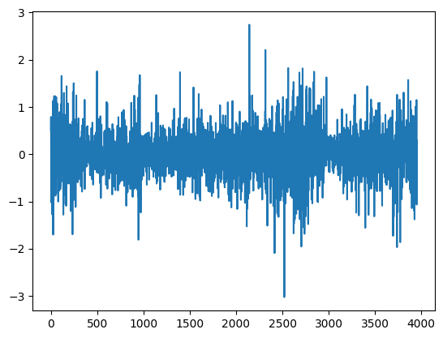

```python
EUR_shifted['%change'].plot()
```

## rolling ( )

Rolling function : pandas creates window over time (past) and applies the function to this window interval. So, looks back to the rows in the back and applies window only to that window, Returns one value per row.

This is windowed calculation.

Returned size of series is the same, just NaNs (false) and true value for each window.

```python
EUR_shifted['pct_change_5_avg'] = EUR_shifted['%change'].rolling(window=5).mean()
EUR_shifted.head(90)
```

|  | date | EUR | EUR_lag_1 | EUR_sub_1 | %change | pct_change_5_avg |
| --- | --- | --- | --- | --- | --- | --- |
| 3953 | 2012-01-01 | 0.771664 | NaN | 0.773932 | NaN | NaN |
| 3952 | 2012-01-02 | 0.773932 | 0.771664 | 0.765684 | 0.293910 | NaN |
| 3951 | 2012-01-03 | 0.765684 | 0.773932 | 0.773249 | -1.065727 | NaN |
| 3950 | 2012-01-04 | 0.773249 | 0.765684 | 0.782138 | 0.988005 | NaN |
| 3949 | 2012-01-05 | 0.782138 | 0.773249 | 0.785862 | 1.149565 | NaN |
| ... | ... | ... | ... | ... | ... | ... |
| 3868 | 2012-03-26 | 0.750214 | 0.753750 | 0.749795 | -0.469121 | -0.206306 |
| 3867 | 2012-03-27 | 0.749795 | 0.750214 | 0.752083 | -0.055851 | -0.212278 |
| 3866 | 2012-03-28 | 0.752083 | 0.749795 | 0.753841 | 0.305150 | -0.039559 |
| 3865 | 2012-03-29 | 0.753841 | 0.752083 | 0.750048 | 0.233751 | 0.004113 |
| 3864 | 2012-03-30 | 0.750048 | 0.753841 | 0.749400 | -0.503157 | -0.097845 |

90 rows × 6 columns

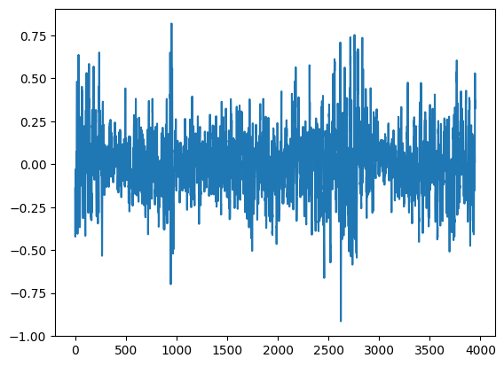

```python
EUR_shifted['pct_change_5_avg'].plot()
```

## Rolling Days

Mechanism the same just base on the time period instead of the row numbers.

Prepare data before rolling days:

```python
# ensure the index is set in the datetime format
# first , change date to datetime format
EUR_shifted['date'] = pd.to_datetime(EUR_shifted['date'])
```

```python
# next sort values by time
EUR_shifted.sort_values(by='date')
```

|  | date | EUR | EUR_lag_1 | EUR_sub_1 | %change | pct_change_5_avg |
| --- | --- | --- | --- | --- | --- | --- |
| 3953 | 2012-01-01 | 0.771664 | NaN | 0.773932 | NaN | NaN |
| 3952 | 2012-01-02 | 0.773932 | 0.771664 | 0.765684 | 0.293910 | NaN |
| 3951 | 2012-01-03 | 0.765684 | 0.773932 | 0.773249 | -1.065727 | NaN |
| 3950 | 2012-01-04 | 0.773249 | 0.765684 | 0.782138 | 0.988005 | NaN |
| 3949 | 2012-01-05 | 0.782138 | 0.773249 | 0.785862 | 1.149565 | NaN |
| ... | ... | ... | ... | ... | ... | ... |
| 4 | 2022-10-24 | 1.012665 | 1.013896 | 1.003852 | -0.121413 | -0.186607 |
| 3 | 2022-10-25 | 1.003852 | 1.012665 | 0.993657 | -0.870278 | -0.278934 |
| 2 | 2022-10-26 | 0.993657 | 1.003852 | 1.001526 | -1.015588 | -0.422209 |
| 1 | 2022-10-27 | 1.001526 | 0.993657 | 1.006649 | 0.791923 | -0.246838 |
| 0 | 2022-10-28 | 1.006649 | 1.001526 | NaN | 0.511519 | -0.140767 |

3954 rows × 6 columns

```python
# set the sorted column of datetime in the index
EUR_shifted = EUR_shifted.set_index('date')
```

Now pandas nows: this is a time series data :

```python
EUR_shifted.head(4)
```

| date | EUR | EUR_lag_1 | EUR_sub_1 | %change | pct_change_5_avg |
| --- | --- | --- | --- | --- | --- |
| 2012-01-01 | 0.771664 | NaN | 0.773932 | NaN | NaN |
| 2012-01-02 | 0.773932 | 0.771664 | 0.765684 | 0.293910 | NaN |
| 2012-01-03 | 0.765684 | 0.773932 | 0.773249 | -1.065727 | NaN |
| 2012-01-04 | 0.773249 | 0.765684 | 0.782138 | 0.988005 | NaN |

Now, we are ready to apply Day rolling mechanism in the datetime index:

```python
EUR_shifted['pct_change_5D'] = EUR_shifted['%change'].rolling('5D').mean()
EUR_shifted.head(50)
```

| date | EUR | EUR_lag_1 | EUR_sub_1 | %change | pct_change_5_avg | pct_change_5D |
| --- | --- | --- | --- | --- | --- | --- |
| 2012-01-01 | 0.771664 | NaN | 0.773932 | NaN | NaN | NaN |
| 2012-01-02 | 0.773932 | 0.771664 | 0.765684 | 0.293910 | NaN | 0.293910 |
| 2012-01-03 | 0.765684 | 0.773932 | 0.773249 | -1.065727 | NaN | -0.385908 |
| 2012-01-04 | 0.773249 | 0.765684 | 0.782138 | 0.988005 | NaN | 0.072063 |
| 2012-01-05 | 0.782138 | 0.773249 | 0.785862 | 1.149565 | NaN | 0.341439 |
| 2012-01-06 | 0.785862 | 0.782138 | 0.786411 | 0.476131 | 0.368377 | 0.368377 |
| 2012-01-07 | 0.786411 | 0.785862 | 0.786102 | 0.069860 | 0.323567 | 0.323567 |
| 2012-01-08 | 0.786102 | 0.786411 | 0.784713 | -0.039292 | 0.528854 | 0.528854 |
| 2012-01-09 | 0.784713 | 0.786102 | 0.782410 | -0.176695 | 0.295914 | 0.295914 |
| 2012-01-10 | 0.782410 | 0.784713 | 0.788248 | -0.293483 | 0.007304 | 0.007304 |
| 2012-01-11 | 0.788248 | 0.782410 | 0.780342 | 0.746156 | 0.061309 | 0.061309 |
| 2012-01-12 | 0.780342 | 0.788248 | 0.788271 | -1.002984 | -0.153260 | -0.153260 |
| 2012-01-13 | 0.788271 | 0.780342 | 0.788706 | 1.016093 | 0.057817 | 0.057817 |
| 2012-01-14 | 0.788706 | 0.788271 | 0.788706 | 0.055184 | 0.104193 | 0.104193 |
| 2012-01-15 | 0.788706 | 0.788706 | 0.788973 | 0.000000 | 0.162890 | 0.162890 |
| 2012-01-16 | 0.788973 | 0.788706 | 0.784891 | 0.033853 | 0.020429 | 0.020429 |
| 2012-01-17 | 0.784891 | 0.788973 | 0.779713 | -0.517381 | 0.117550 | 0.117550 |
| 2012-01-18 | 0.779713 | 0.784891 | 0.772903 | -0.659709 | -0.217611 | -0.217611 |
| 2012-01-19 | 0.772903 | 0.779713 | 0.772738 | -0.873398 | -0.403327 | -0.403327 |
| 2012-01-20 | 0.772738 | 0.772903 | 0.772977 | -0.021348 | -0.407597 | -0.407597 |
| 2012-01-21 | 0.772977 | 0.772738 | 0.773276 | 0.030929 | -0.408182 | -0.408182 |
| 2012-01-22 | 0.773276 | 0.772977 | 0.767211 | 0.038682 | -0.296969 | -0.296969 |
| 2012-01-23 | 0.767211 | 0.773276 | 0.768998 | -0.784325 | -0.321892 | -0.321892 |
| 2012-01-24 | 0.768998 | 0.767211 | 0.770765 | 0.232922 | -0.100628 | -0.100628 |
| 2012-01-25 | 0.770765 | 0.768998 | 0.760141 | 0.229780 | -0.050403 | -0.050403 |
| 2012-01-26 | 0.760141 | 0.770765 | 0.758111 | -1.378371 | -0.332263 | -0.332263 |
| 2012-01-27 | 0.758111 | 0.760141 | 0.756430 | -0.267056 | -0.393410 | -0.393410 |
| 2012-01-28 | 0.756430 | 0.758111 | 0.756400 | -0.221735 | -0.280892 | -0.280892 |
| 2012-01-29 | 0.756400 | 0.756430 | 0.762416 | -0.003966 | -0.328270 | -0.328270 |
| 2012-01-30 | 0.762416 | 0.756400 | 0.766293 | 0.795346 | -0.215156 | -0.215156 |
| 2012-01-31 | 0.766293 | 0.762416 | 0.757151 | 0.508515 | 0.162221 | 0.162221 |
| 2012-02-01 | 0.757151 | 0.766293 | 0.759782 | -1.193016 | -0.022971 | -0.022971 |
| 2012-02-02 | 0.759782 | 0.757151 | 0.762969 | 0.347487 | 0.090873 | 0.090873 |
| 2012-02-03 | 0.762969 | 0.759782 | 0.760200 | 0.419462 | 0.175559 | 0.175559 |
| 2012-02-04 | 0.760200 | 0.762969 | 0.760450 | -0.362924 | -0.056095 | -0.056095 |
| 2012-02-05 | 0.760450 | 0.760200 | 0.761640 | 0.032886 | -0.151221 | -0.151221 |
| 2012-02-06 | 0.761640 | 0.760450 | 0.755206 | 0.156486 | 0.118679 | 0.118679 |
| 2012-02-07 | 0.755206 | 0.761640 | 0.754624 | -0.844756 | -0.119769 | -0.119769 |
| 2012-02-08 | 0.754624 | 0.755206 | 0.752178 | -0.077065 | -0.219075 | -0.219075 |
| 2012-02-09 | 0.752178 | 0.754624 | 0.758335 | -0.324135 | -0.211317 | -0.211317 |
| 2012-02-10 | 0.758335 | 0.752178 | 0.757750 | 0.818556 | -0.054183 | -0.054183 |
| 2012-02-11 | 0.757750 | 0.758335 | 0.757850 | -0.077143 | -0.100908 | -0.100908 |
| 2012-02-12 | 0.757850 | 0.757750 | 0.756892 | 0.013197 | 0.070682 | 0.070682 |
| 2012-02-13 | 0.756892 | 0.757850 | 0.760716 | -0.126410 | 0.060813 | 0.060813 |
| 2012-02-14 | 0.760716 | 0.756892 | 0.764118 | 0.505224 | 0.226685 | 0.226685 |
| 2012-02-15 | 0.764118 | 0.760716 | 0.763161 | 0.447210 | 0.152416 | 0.152416 |
| 2012-02-16 | 0.763161 | 0.764118 | 0.760429 | -0.125242 | 0.142796 | 0.142796 |
| 2012-02-17 | 0.760429 | 0.763161 | 0.761151 | -0.357985 | 0.068559 | 0.068559 |
| 2012-02-18 | 0.761151 | 0.760429 | 0.760700 | 0.094946 | 0.112831 | 0.112831 |
| 2012-02-19 | 0.760700 | 0.761151 | 0.754918 | -0.059252 | -0.000065 | -0.000065 |

## cumsum ( )

Cumulative sum function as transformation function. The value is adding cumulativly , to the following rows.

```python
forex.head(2)
```

|  | date | EUR | GBP | INR | AUD | CAD | SGD | CHF | MYR | JPY | ... | SAR | ZAR | LKR | SEK | TWD | THB | TTD | TRY | AED | VEF |
| --- | --- | --- | --- | --- | --- | --- | --- | --- | --- | --- | --- | --- | --- | --- | --- | --- | --- | --- | --- | --- | --- |
| 3953 | 2012-01-01 | 0.771664 | 0.644185 | 53.060001 | 0.979672 | 1.02160 | 1.296500 | 0.938550 | 3.1690 | 77.115000 | ... | 3.75025 | 8.080150 | 115.330002 | 6.905100 | 30.275000 | 31.545 | 6.350 | 1.892000 | 3.673050 | 4.3 |
| 3952 | 2012-01-02 | 0.773932 | 0.645401 | 53.307503 | 0.978394 | 1.02071 | 1.297524 | 0.940457 | 3.1724 | 76.910073 | ... | 3.75004 | 8.078046 | 113.899991 | 6.905551 | 30.285639 | 31.544 | 6.438 | 1.895794 | 3.673099 | 4.3 |

2 rows × 54 columns

We copied data as working on the window is risky.

```python
pound = forex[['date', 'GBP']].copy()
pound.head(2)
```

|  | date | GBP |
| --- | --- | --- |
| 3953 | 2012-01-01 | 0.644185 |
| 3952 | 2012-01-02 | 0.645401 |

Let's create cumulative value of pounds:

```python
pound['cumsum'] = pound.loc[:,'GBP'].cumsum()
pound
```

|  | date | GBP | cumsum |
| --- | --- | --- | --- |
| 3953 | 2012-01-01 | 0.644185 | 0.644185 |
| 3952 | 2012-01-02 | 0.645401 | 1.289586 |
| 3951 | 2012-01-03 | 0.638806 | 1.928392 |
| 3950 | 2012-01-04 | 0.639650 | 2.568042 |
| 3949 | 2012-01-05 | 0.645945 | 3.213987 |
| ... | ... | ... | ... |
| 4 | 2022-10-24 | 0.885427 | 2829.428348 |
| 3 | 2022-10-25 | 0.871802 | 2830.300150 |
| 2 | 2022-10-26 | 0.861563 | 2831.161713 |
| 1 | 2022-10-27 | 0.864250 | 2832.025963 |
| 0 | 2022-10-28 | 0.864114 | 2832.890077 |

3954 rows × 3 columns

## cumprod( )

Computes (multiplies) cumulative product.

x1 * x2 * x3 * xn

```python
pound['cumprod'] = pound.loc[:,'GBP'].cumprod()
pound
```

|  | date | GBP | cumsum | cumprod |
| --- | --- | --- | --- | --- |
| 3953 | 2012-01-01 | 0.644185 | 0.644185 | 6.441850e-01 |
| 3952 | 2012-01-02 | 0.645401 | 1.289586 | 4.157576e-01 |
| 3951 | 2012-01-03 | 0.638806 | 1.928392 | 2.655885e-01 |
| 3950 | 2012-01-04 | 0.639650 | 2.568042 | 1.698837e-01 |
| 3949 | 2012-01-05 | 0.645945 | 3.213987 | 1.097355e-01 |
| ... | ... | ... | ... | ... |
| 4 | 2022-10-24 | 0.885427 | 2829.428348 | 4.940656e-324 |
| 3 | 2022-10-25 | 0.871802 | 2830.300150 | 4.940656e-324 |
| 2 | 2022-10-26 | 0.861563 | 2831.161713 | 4.940656e-324 |
| 1 | 2022-10-27 | 0.864250 | 2832.025963 | 4.940656e-324 |
| 0 | 2022-10-28 | 0.864114 | 2832.890077 | 4.940656e-324 |

3954 rows × 4 columns

## transform ( )

Function very similar to agg( ) function.

Keep the brackets when specifying transformation functions:

```python
pound['GBP'].transform(['shift', 'pct_change', 'cumsum', 'diff'])
```

|  | shift | pct_change | cumsum | diff |
| --- | --- | --- | --- | --- |
| 3953 | NaN | NaN | 0.644185 | NaN |
| 3952 | 0.644185 | 0.001888 | 1.289586 | 0.001216 |
| 3951 | 0.645401 | -0.010218 | 1.928392 | -0.006595 |
| 3950 | 0.638806 | 0.001321 | 2.568042 | 0.000844 |
| 3949 | 0.639650 | 0.009841 | 3.213987 | 0.006295 |
| ... | ... | ... | ... | ... |
| 4 | 0.884421 | 0.001137 | 2829.428348 | 0.001006 |
| 3 | 0.885427 | -0.015388 | 2830.300150 | -0.013625 |
| 2 | 0.871802 | -0.011745 | 2831.161713 | -0.010239 |
| 1 | 0.861563 | 0.003119 | 2832.025963 | 0.002687 |
| 0 | 0.864250 | -0.000157 | 2832.890077 | -0.000136 |

3954 rows × 4 columns

Compute 3 functions on each selected column:

This is the multi-level index.

```python
result = forex[['EUR', 'GBP', 'JPY']].transform(['shift', 'cumsum', 'diff'])
result
```

|  | EUR shift | EUR cumsum | EUR diff | GBP shift | GBP cumsum | GBP diff | JPY shift | JPY cumsum | JPY diff |
| --- | --- | --- | --- | --- | --- | --- | --- | --- | --- |
| 3953 | NaN | 0.771664 | NaN | NaN | 0.644185 | NaN | NaN | 77.115000 | NaN |
| 3952 | 0.771664 | 1.545596 | 0.002268 | 0.644185 | 1.289586 | 0.001216 | 77.115000 | 154.025073 | -0.204927 |
| 3951 | 0.773932 | 2.311280 | -0.008248 | 0.645401 | 1.928392 | -0.006595 | 76.910073 | 230.695910 | -0.239236 |
| 3950 | 0.765684 | 3.084529 | 0.007565 | 0.638806 | 2.568042 | 0.000844 | 76.670837 | 307.392893 | 0.026146 |
| 3949 | 0.773249 | 3.866667 | 0.008889 | 0.639650 | 3.213987 | 0.006295 | 76.696983 | 384.564192 | 0.474316 |
| ... | ... | ... | ... | ... | ... | ... | ... | ... | ... |
| 4 | 1.013896 | 3365.137977 | -0.001231 | 0.884421 | 2829.428348 | 0.001006 | 147.406414 | 426178.349295 | 1.343242 |
| 3 | 1.012665 | 3366.141829 | -0.008813 | 0.885427 | 2830.300150 | -0.013625 | 148.749656 | 426326.170152 | -0.928799 |
| 2 | 1.003852 | 3367.135486 | -0.010195 | 0.871802 | 2831.161713 | -0.010239 | 147.820857 | 426472.719614 | -1.271395 |
| 1 | 0.993657 | 3368.137012 | 0.007869 | 0.861563 | 2832.025963 | 0.002687 | 146.549462 | 426618.730980 | -0.538096 |
| 0 | 1.001526 | 3369.143661 | 0.005123 | 0.864250 | 2832.890077 | -0.000136 | 146.011366 | 426766.430734 | 1.688388 |

3954 rows × 9 columns

Print the columns from the result dataframe, to confirm the multi-level indexing.

```python
result.columns
```

```
MultiIndex([('EUR',  'shift'),
            ('EUR', 'cumsum'),
            ('EUR',   'diff'),
            ('GBP',  'shift'),
            ('GBP', 'cumsum'),
            ('GBP',   'diff'),
            ('JPY',  'shift'),
            ('JPY', 'cumsum'),
            ('JPY',   'diff')],
           )
```

This is a tuple object of python.

```python
result[('EUR', 'shift')]
```

|  | EUR shift |
| --- | --- |
| 3953 | NaN |
| 3952 | 0.771664 |
| 3951 | 0.773932 |
| 3950 | 0.765684 |
| 3949 | 0.773249 |
| ... | ... |
| 4 | 1.013896 |
| 3 | 1.012665 |
| 2 | 1.003852 |
| 1 | 0.993657 |
| 0 | 1.001526 |

3954 rows × 1 columns

**dtype:** float64

Flatten , the multi-level column names:

We created list as tuple is not changeable.

Next, we for to comprehension function to swap existing name with strings.

We can create function to flatten the heading of the table from muli-level to flat one.

```python
result.columns
```

```
MultiIndex([('EUR',  'shift'),
            ('EUR', 'cumsum'),
            ('EUR',   'diff'),
            ('GBP',  'shift'),
            ('GBP', 'cumsum'),
            ('GBP',   'diff'),
            ('JPY',  'shift'),
            ('JPY', 'cumsum'),
            ('JPY',   'diff')],
           )
```

```python
result.columns = [x[0] + '_' + x[1] for x in list(result.columns)]
result
```

|  | EUR_shift | EUR_cumsum | EUR_diff | GBP_shift | GBP_cumsum | GBP_diff | JPY_shift | JPY_cumsum | JPY_diff |
| --- | --- | --- | --- | --- | --- | --- | --- | --- | --- |
| 3953 | NaN | 0.771664 | NaN | NaN | 0.644185 | NaN | NaN | 77.115000 | NaN |
| 3952 | 0.771664 | 1.545596 | 0.002268 | 0.644185 | 1.289586 | 0.001216 | 77.115000 | 154.025073 | -0.204927 |
| 3951 | 0.773932 | 2.311280 | -0.008248 | 0.645401 | 1.928392 | -0.006595 | 76.910073 | 230.695910 | -0.239236 |
| 3950 | 0.765684 | 3.084529 | 0.007565 | 0.638806 | 2.568042 | 0.000844 | 76.670837 | 307.392893 | 0.026146 |
| 3949 | 0.773249 | 3.866667 | 0.008889 | 0.639650 | 3.213987 | 0.006295 | 76.696983 | 384.564192 | 0.474316 |
| ... | ... | ... | ... | ... | ... | ... | ... | ... | ... |
| 4 | 1.013896 | 3365.137977 | -0.001231 | 0.884421 | 2829.428348 | 0.001006 | 147.406414 | 426178.349295 | 1.343242 |
| 3 | 1.012665 | 3366.141829 | -0.008813 | 0.885427 | 2830.300150 | -0.013625 | 148.749656 | 426326.170152 | -0.928799 |
| 2 | 1.003852 | 3367.135486 | -0.010195 | 0.871802 | 2831.161713 | -0.010239 | 147.820857 | 426472.719614 | -1.271395 |
| 1 | 0.993657 | 3368.137012 | 0.007869 | 0.861563 | 2832.025963 | 0.002687 | 146.549462 | 426618.730980 | -0.538096 |
| 0 | 1.001526 | 3369.143661 | 0.005123 | 0.864250 | 2832.890077 | -0.000136 | 146.011366 | 426766.430734 | 1.688388 |

3954 rows × 9 columns

```python
# dictionary with transformation
forex.transform({'EUR': 'shift', 'GBP': 'diff', 'JPY': 'cumsum'})
```

|  | EUR | GBP | JPY |
| --- | --- | --- | --- |
| 3953 | NaN | NaN | 77.115000 |
| 3952 | 0.771664 | 0.001216 | 154.025073 |
| 3951 | 0.773932 | -0.006595 | 230.695910 |
| 3950 | 0.765684 | 0.000844 | 307.392893 |
| 3949 | 0.773249 | 0.006295 | 384.564192 |
| ... | ... | ... | ... |
| 4 | 1.013896 | 0.001006 | 426178.349295 |
| 3 | 1.012665 | -0.013625 | 426326.170152 |
| 2 | 1.003852 | -0.010239 | 426472.719614 |
| 1 | 0.993657 | 0.002687 | 426618.730980 |
| 0 | 1.001526 | -0.000136 | 426766.430734 |

3954 rows × 3 columns

We need to be careful because in transformation aggregation functions are not allowed.

# User function transformation

This is the same as aggregation function. We need remember that dimension (size) must be the same.

```python
pound
```

|  | date | GBP | cumsum | cumprod |
| --- | --- | --- | --- | --- |
| 3953 | 2012-01-01 | 0.644185 | 0.644185 | 6.441850e-01 |
| 3952 | 2012-01-02 | 0.645401 | 1.289586 | 4.157576e-01 |
| 3951 | 2012-01-03 | 0.638806 | 1.928392 | 2.655885e-01 |
| 3950 | 2012-01-04 | 0.639650 | 2.568042 | 1.698837e-01 |
| 3949 | 2012-01-05 | 0.645945 | 3.213987 | 1.097355e-01 |
| ... | ... | ... | ... | ... |
| 4 | 2022-10-24 | 0.885427 | 2829.428348 | 4.940656e-324 |
| 3 | 2022-10-25 | 0.871802 | 2830.300150 | 4.940656e-324 |
| 2 | 2022-10-26 | 0.861563 | 2831.161713 | 4.940656e-324 |
| 1 | 2022-10-27 | 0.864250 | 2832.025963 | 4.940656e-324 |
| 0 | 2022-10-28 | 0.864114 | 2832.890077 | 4.940656e-324 |

3954 rows × 4 columns

Create own function and use with the dataframe:

```python
def add_n(x, n, m):
  # adding by two parameters, first is the column , secend selected value
  return x+n+m

  # in this method user can use his value in the function argument

pound['added_1'] = pound.GBP.transform(add_n, axis=0, n=100, m=1000) # position argument, keyword argument, function argument
pound
```

|  | date | GBP | cumsum | cumprod | added_1 |
| --- | --- | --- | --- | --- | --- |
| 3953 | 2012-01-01 | 0.644185 | 0.644185 | 6.441850e-01 | 1100.644185 |
| 3952 | 2012-01-02 | 0.645401 | 1.289586 | 4.157576e-01 | 1100.645401 |
| 3951 | 2012-01-03 | 0.638806 | 1.928392 | 2.655885e-01 | 1100.638806 |
| 3950 | 2012-01-04 | 0.639650 | 2.568042 | 1.698837e-01 | 1100.639650 |
| 3949 | 2012-01-05 | 0.645945 | 3.213987 | 1.097355e-01 | 1100.645945 |
| ... | ... | ... | ... | ... | ... |
| 4 | 2022-10-24 | 0.885427 | 2829.428348 | 4.940656e-324 | 1100.885427 |
| 3 | 2022-10-25 | 0.871802 | 2830.300150 | 4.940656e-324 | 1100.871802 |
| 2 | 2022-10-26 | 0.861563 | 2831.161713 | 4.940656e-324 | 1100.861563 |
| 1 | 2022-10-27 | 0.864250 | 2832.025963 | 4.940656e-324 | 1100.864250 |
| 0 | 2022-10-28 | 0.864114 | 2832.890077 | 4.940656e-324 | 1100.864114 |

3954 rows × 5 columns

## Standardized data

- standardized data
- normalized data
- z score
- z value

```python
realtor_data
```

|  | status | bed | bath | acre_lot | city | state | zip_code | house_size | prev_sold_date | price |
| --- | --- | --- | --- | --- | --- | --- | --- | --- | --- | --- |
| 0 | for_sale | 3.0 | 2.0 | 0.12 | Adjuntas | Puerto Rico | 601.0 | 920.0 | NaT | 105000.0 |
| 1 | for_sale | 4.0 | 2.0 | 0.08 | Adjuntas | Puerto Rico | 601.0 | 1527.0 | NaT | 80000.0 |
| 2 | for_sale | 2.0 | 1.0 | 0.15 | Juana Diaz | Puerto Rico | 795.0 | 748.0 | NaT | 67000.0 |
| 3 | for_sale | 4.0 | 2.0 | 0.10 | Ponce | Puerto Rico | 731.0 | 1800.0 | NaT | 145000.0 |
| 4 | for_sale | 6.0 | 2.0 | 0.05 | Mayaguez | Puerto Rico | 680.0 | NaN | NaT | 65000.0 |
| ... | ... | ... | ... | ... | ... | ... | ... | ... | ... | ... |
| 904961 | for_sale | 2.0 | 2.0 | NaN | New York City | New York | 10463.0 | NaN | 2021-08-13 | 359000.0 |
| 904962 | for_sale | 2.0 | 2.0 | NaN | Bronx | New York | 10463.0 | 1200.0 | NaT | 299000.0 |
| 904963 | for_sale | NaN | 1.0 | NaN | Bronx | New York | 10463.0 | NaN | NaT | 120000.0 |
| 904964 | for_sale | 3.0 | 2.0 | NaN | Bronx | New York | 10463.0 | NaN | NaT | 449000.0 |
| 904965 | for_sale | 3.0 | 3.0 | NaN | New York City | New York | 10463.0 | 1677.0 | 2007-06-27 | 850000.0 |

904966 rows × 10 columns

standardize the value:

We can create a function to standardize the values from the dataset. The function formula is below:

```
#

(value - mean() / std() )
```

We subtracted average from each value of series , and next divided by std deviation.

```python
# z_score function

def standardize(x):
  z_score = (x - x.mean()) / x.std()
  return z_score
```

```python
standardize(realtor_data.price)
```

|  | price |
| --- | --- |
| 0 | -0.314293 |
| 1 | -0.324465 |
| 2 | -0.329755 |
| 3 | -0.298018 |
| 4 | -0.330569 |
| ... | ... |
| 904961 | -0.210945 |
| 904962 | -0.235358 |
| 904963 | -0.308190 |
| 904964 | -0.174325 |
| 904965 | -0.011164 |

904966 rows × 1 columns

**dtype:** float64

```python
standardize(realtor_data.price).mean()
```

```
np.float64(3.2665201827416626e-18)
```

```python
standardize(realtor_data.price).std()
```

```
0.9999999999998388
```

Let's apply this function using transform method. This is the power of transform method , as we can apply it on few columns

```python
realtor_data[['price', 'bed', 'bath', 'house_size']].transform(standardize)
```

|  | price | bed | bath | house_size |
| --- | --- | --- | --- | --- |
| 0 | -0.314293 | -0.160842 | -0.250688 | -0.399933 |
| 1 | -0.324465 | 0.323346 | -0.250688 | -0.200695 |
| 2 | -0.329755 | -0.645031 | -0.768388 | -0.456390 |
| 3 | -0.298018 | 0.323346 | -0.250688 | -0.111087 |
| 4 | -0.330569 | 1.291723 | -0.250688 | NaN |
| ... | ... | ... | ... | ... |
| 904961 | -0.210945 | -0.645031 | -0.250688 | NaN |
| 904962 | -0.235358 | -0.645031 | -0.250688 | -0.308028 |
| 904963 | -0.308190 | NaN | -0.768388 | NaN |
| 904964 | -0.174325 | -0.160842 | -0.250688 | NaN |
| 904965 | -0.011164 | -0.160842 | 0.267011 | -0.151460 |

904966 rows × 4 columns